# Final Exam - Predicting Demand

Vishal Gupta

5/1/2019

```r
library(dplyr)
library(ROCR)
library(tidyr)
library(caTools)
library(randomForest)
library(rpart)
library(rpart.plot)
library(caret)
library(e1071)
```

#### Problem 1 - Exploratory Data Analysis

Which season has the most rentals?

```r
bikes = read.csv("~/Downloads/bikes.csv")
bikes %>% group_by(season) %>% summarise(ct = sum(count)) %>% arrange(desc(ct))
```

```
## # A tibble: 4 x 2
##   season     ct
##    <int>  <int>
## 1      3 640662
## 2      2 588282
## 3      4 544034
## 4      1 312498
```

What is the average temerature in Celsius?

```r
bikes %>% summarise(mean(temp))
```

```
##   mean(temp)
## 1   20.23086
```

What is the average temerature in Celsius during the high demand hours?

High demand is defined by demand_level = 1.

```r
bikes %>% filter(demand_level == 1) %>% summarise(mean(temp))
```

```
##   mean(temp)
## 1   24.48587
```

#### Problem 2.1 - Preparing the Data

We will now split the data into a training and testing set. To do this, we use the sample.split() function. Which variable will be used in this function?

- temp
- count
- **demand_level**
- season

Set your random seed to 100 and create a training and test set using the sample.split() function in the caTools library, with 70% of the observations in the training set and 30% in the testing set.

```r
set.seed(100)
spl = sample.split(bikes$demand_level,SplitRatio = 0.7)
bikesTrain = bikes[spl==T,]
bikesTest = bikes[spl==F,]
```

Why do we use the sample.split() function?

- It is the most convenient way to randomly split the data
- It balances the independent variables between the training and testing sets
- **It balances the dependent variable between the training and testing sets**

How many observation are there in the training set?

```r
nrow(bikesTrain)
```

```
## [1] 7620
```

#### Problem 2.2 - Simple Logistic Regression

Train a logistic regression model using temp as the independent variable. What is the coefficient of temp?

```r
bikes_model = glm(formula = demand_level ~ temp, family = "binomial", data = bikesTrain)
summary(bikes_model)
```

```
##
## Call:
## glm(formula = demand_level ~ temp, family = "binomial", data = bikesTrain)
##
## Deviance Residuals:
##     Min       1Q   Median       3Q      Max
## -1.6313  -0.8673  -0.5588   1.0896   2.5204
##
## Coefficients:
##              Estimate Std. Error z value Pr(>|z|)
## (Intercept) -3.224047   0.090173  -35.75   <2e-16 ***
## temp         0.110214   0.003798   29.02   <2e-16 ***
## ---
## Signif. codes:  0 '***' 0.001 '**' 0.01 '*' 0.05 '.' 0.1 ' ' 1
##
## (Dispersion parameter for binomial family taken to be 1)
##
##     Null deviance: 9304.5  on 7619  degrees of freedom
## Residual deviance: 8308.6  on 7618  degrees of freedom
## AIC: 8312.6
##
## Number of Fisher Scoring iterations: 4
```

#### Problem 2.3 - Simple Logistic Regression

Using your logistic regression model, obtain predictions on the test set. Then, using a probability threshold of 0.5, create a confusion matrix for the test set. What is the (test) accuracy of your logistic regression model?

```r
y_pred = (predict(bikes_model, bikesTest, ,type = 'response') >0.5)
y_true = bikesTest$demand_level
table(y_pred,y_true)
```

```
##        y_true
## y_pred     0    1
##   FALSE 2109  707
##   TRUE   178  272
```

```r
sum(y_pred==y_true)/nrow(bikesTest)
```

```
## [1] 0.7290263
```

Our baseline model in classification is to always predict the most frequent outcome in the test set. What is the (test) accuracy of this baseline model?

```r
sum(0==y_true)/nrow(bikesTest)
```

```
## [1] 0.7002449
```

What is the true positive rate of your logistic regression model?

```r
true_inds = (y_true == 1)
sum(y_pred[true_inds] == T)/sum(true_inds)
```

```
## [1] 0.2778345
```

What is the false positive rate of your logistic regression model?

```r
false_inds = (y_true == 0)
sum(y_pred[false_inds] == T)/sum(false_inds)
```

```
## [1] 0.07783122
```

Currently, we are predicting many more low demand observations than high demand observations. Which of the following is a way to change that?

- It is impossible to predict more high demand with this model. To change these results, another model can be used.
- **To predict more high demand, decrease the prediction threshold.**
- To predict more high demand hours, increase the prediction threshold.
- To predict more high demand hours, create more observations with high demand.

#### Problem 3.1 - Adding More Variables

We would now like to train a logistic regression model using all of the variables in the training set. Which of the following is true?

```r
cor(bikesTrain)
```

```
##                          X       season       holiday   workingday
## X             1.0000000000  0.477508915  0.0177901870 -0.017143792
## season        0.4775089147  1.000000000  0.0330355326 -0.020039728
## holiday       0.0177901870  0.033035533  1.0000000000 -0.260129211
## workingday   -0.0171437919 -0.020039728 -0.2601292107  1.000000000
## weather      -0.0003536354  0.004540406 -0.0113633530  0.032068520
## temp          0.1694877378  0.255679945  0.0079079843  0.022737405
## atemp         0.1703436925  0.260329259  0.0027551880  0.016945385
## humidity      0.0316188055  0.189643955  0.0021119723 -0.009047056
## windspeed    -0.0917498363 -0.146484678 -0.0030807753  0.017049203
## count         0.3053387194  0.162735542 -0.0060414854  0.005468822
## demand_level  0.2702103425  0.141840845  0.0110241271 -0.020998940
## hour          0.0054894445 -0.002032923 -0.0004844969  0.005291814
##                    weather         temp        atemp     humidity
## X            -0.0003536354  0.169487738  0.170343693  0.031618806
## season        0.0045404062  0.255679945  0.260329259  0.189643955
## holiday      -0.0113633530  0.007907984  0.002755188  0.002111972
## workingday    0.0320685202  0.022737405  0.016945385 -0.009047056
## weather       1.0000000000 -0.057343350 -0.056681628  0.404281785
## temp         -0.0573433501  1.000000000  0.984534404 -0.061418725
## atemp        -0.0566816277  0.984534404  1.000000000 -0.039364305
## humidity      0.4042817848 -0.061418725 -0.039364305  1.000000000
## windspeed     0.0034005948 -0.021821145 -0.060707430 -0.322395699
## count        -0.1286613782  0.387779544  0.381732010 -0.316203983
## demand_level -0.1123167345  0.351732043  0.346128308 -0.262470112
## hour         -0.0317742480  0.149879257  0.146144175 -0.281187229
##                 windspeed        count demand_level          hour
## X            -0.091749836  0.305338719   0.27021034  0.0054894445
## season       -0.146484678  0.162735542   0.14184085 -0.0020329227
## holiday      -0.003080775 -0.006041485   0.01102413 -0.0004844969
## workingday    0.017049203  0.005468822  -0.02099894  0.0052918142
## weather       0.003400595 -0.128661378  -0.11231673 -0.0317742480
## temp         -0.021821145  0.387779544   0.35173204  0.1498792569
## atemp        -0.060707430  0.381732010   0.34612831  0.1461441749
## humidity     -0.322395699 -0.316203983  -0.26247011 -0.2811872287
## windspeed     1.000000000  0.102040890   0.07051838  0.1426814492
## count         0.102040890  1.000000000   0.82593486  0.4141504553
## demand_level  0.070518379  0.825934859   1.00000000  0.2842562511
## hour          0.142681449  0.414150455   0.28425625  1.0000000000
```

- Weather and temp are highly correlated.
- Season and weather are highly correlated.
- **Workingday and holiday are not highly correlated.**
- **Temp and atemp are highly correlated.**

Train a logistic regression model now using all of the following variables in the training set:

season, holiday, workingday, weather, temp, humidity, windspeed, and hour

Which of the following variables are significant at a level of 0.001 or less?

```r
bikes_model2 = glm(demand_level ~ season + holiday + workingday + weather + temp + humidity + windspeed + hour, bikesTrain, family = 'binomial')
summary(bikes_model2)
```

```
##
## Call:
## glm(formula = demand_level ~ season + holiday + workingday +
##     weather + temp + humidity + windspeed + hour, family = "binomial",
##     data = bikesTrain)
##
## Deviance Residuals:
##     Min       1Q   Median       3Q      Max
## -2.1282  -0.7468  -0.4471   0.8365   2.8967
##
## Coefficients:
##              Estimate Std. Error z value Pr(>|z|)
## (Intercept) -2.895413   0.184754 -15.672  < 2e-16 ***
## season       0.342095   0.029190  11.719  < 2e-16 ***
## holiday     -0.016277   0.169255  -0.096  0.92339
## workingday  -0.175048   0.063433  -2.760  0.00579 **
## weather     -0.026242   0.052297  -0.502  0.61582
## temp         0.097964   0.004078  24.025  < 2e-16 ***
## humidity    -0.029654   0.001863 -15.915  < 2e-16 ***
## windspeed    0.003451   0.003748   0.921  0.35706
## hour         0.074677   0.004497  16.604  < 2e-16 ***
## ---
## Signif. codes:  0 '***' 0.001 '**' 0.01 '*' 0.05 '.' 0.1 ' ' 1
##
## (Dispersion parameter for binomial family taken to be 1)
##
##     Null deviance: 9304.5  on 7619  degrees of freedom
## Residual deviance: 7389.5  on 7611  degrees of freedom
## AIC: 7407.5
##
## Number of Fisher Scoring iterations: 5
```

- **season**
- holiday
- workingday
- weather
- **temp**
- **humidity**
- windspeed
- **hour**

#### Problem 3.2 - Adding More Variables

Using your new logistic regression model, obtain predictions on the test set. Then, using a probability threshold of 0.5, create a confusion matrix for the test set.

```r
y_pred = (predict(bikes_model2, bikesTest, ,type = 'response') >0.5)
y_true = bikesTest$demand_level
table(y_pred,y_true)
```

```
##        y_true
## y_pred     0    1
##   FALSE 2039  512
##   TRUE   248  467
```

What is the (test) accuracy of your logistic regression model?

```r
sum(y_pred==y_true)/nrow(bikesTest)
```

```
## [1] 0.7672994
```

Which of the following is true?

- Close to a third of time that there is high demand, the model will predict high demand.
- **Almost half of the times that there is high demand, the model will predict high demand.**
- About 75% of the times that there is high demand, the model will predict high demand.
- About 10% of the times that there is low demand, the model will predict high demand.
- About 25% of the times that there is low demand, the model will predict high demand.
- About 7% of the times that there is low demand, the model will predict high demand.

Plot the ROC curve for your logistic regression model. Which logistic regression threshold is associated with the lower-left corner of the ROC plot (true positive rate 0 and false positive rate 0)?

- 0
- 0.5
- **1**

At roughly which logistic regression cutoff does the model achieve a true positive rate of 80% and a false positive rate of 40%?

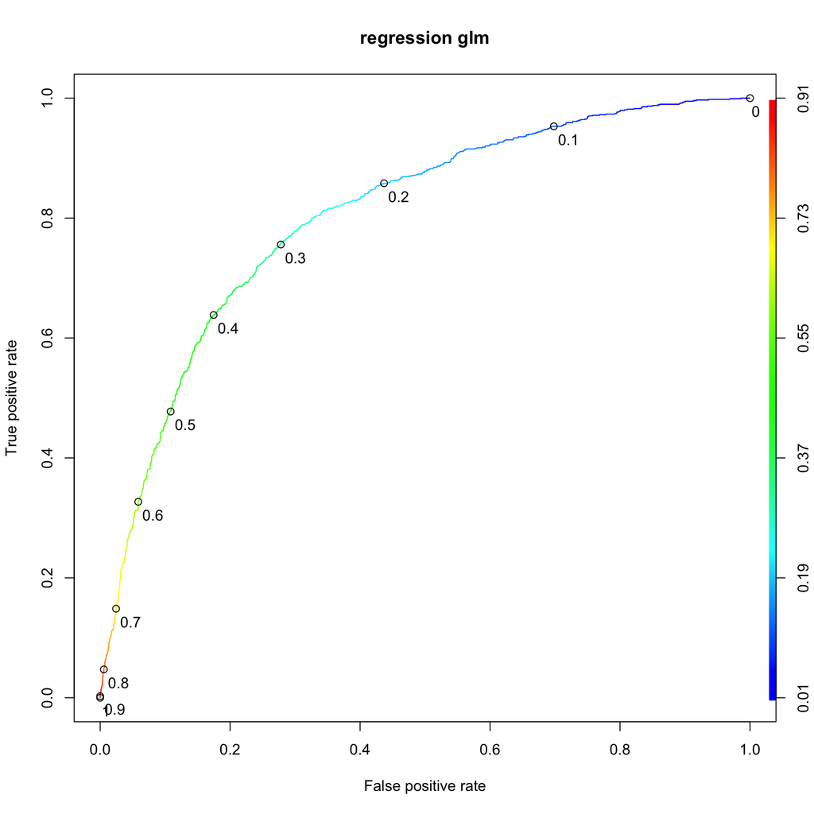

```r
y_pred = predict(bikes_model2, bikesTest, ,type = 'response')
ROCRpred = prediction(y_pred, y_true)
ROCRperf = performance(ROCRpred, "tpr", "fpr")
plot(ROCRperf, main="regression glm", colorize=TRUE, print.cutoffs.at=seq(0,1,by=0.1), text.adj=c(-0.2,1.7))
```

- 0.01
- **0.19**
- 0.37
- 0.55
- 0.73
- 0.91

What is the AUC for your logistic regression model?

```r
as.numeric(performance(ROCRpred, "auc")@y.values)
```

```
## [1] 0.8031658
```

#### Problem 4.1 - CART

Set the random seed to 100.

Then use the caret package and the train function to perform 10-fold cross validation with the training data set to select the best cp value for a CART model that predicts the dependent variable demand_level using all of the possible independent variables except count which was used to define the dependent variable. Select the cp value from a grid consisting of the values 0.0001, 0.0002, 0.0003, …, 0.02.

```r
set.seed(100)
summary(bikesTrain)
```

```
##        X             season         holiday          workingday
##  Min.   :    1   Min.   :1.000   Min.   :0.00000   Min.   :0.0000
##  1st Qu.: 2762   1st Qu.:2.000   1st Qu.:0.00000   1st Qu.:0.0000
##  Median : 5458   Median :3.000   Median :0.00000   Median :1.0000
##  Mean   : 5459   Mean   :2.513   Mean   :0.03123   Mean   :0.6773
##  3rd Qu.: 8180   3rd Qu.:4.000   3rd Qu.:0.00000   3rd Qu.:1.0000
##  Max.   :10886   Max.   :4.000   Max.   :1.00000   Max.   :1.0000
##     weather           temp           atemp          humidity
##  Min.   :1.000   Min.   : 0.82   Min.   : 0.76   Min.   :  0.00
##  1st Qu.:1.000   1st Qu.:13.94   1st Qu.:16.66   1st Qu.: 47.00
##  Median :1.000   Median :20.50   Median :24.24   Median : 62.00
##  Mean   :1.418   Mean   :20.28   Mean   :23.71   Mean   : 62.01
##  3rd Qu.:2.000   3rd Qu.:26.24   3rd Qu.:31.06   3rd Qu.: 77.00
##  Max.   :4.000   Max.   :41.00   Max.   :45.45   Max.   :100.00
##    windspeed          count        demand_level         hour
##  Min.   : 0.000   Min.   :  1.0   Min.   :0.0000   Min.   : 0.00
##  1st Qu.: 7.002   1st Qu.: 42.0   1st Qu.:0.0000   1st Qu.: 5.00
##  Median :11.001   Median :147.0   Median :0.0000   Median :11.00
##  Mean   :12.740   Mean   :190.4   Mean   :0.2996   Mean   :11.46
##  3rd Qu.:16.998   3rd Qu.:283.0   3rd Qu.:1.0000   3rd Qu.:17.00
##  Max.   :56.997   Max.   :970.0   Max.   :1.0000   Max.   :23.00
```

```r
#bikesTrain$season = as.factor(bikesTrain$season)
bikesTrain$holiday = as.factor(bikesTrain$holiday)
bikesTrain$workingday = as.factor(bikesTrain$workingday)
#bikesTrain$weather = as.factor(bikesTrain$weather)
bikesTrain$demand_level = as.factor(bikesTrain$demand_level)

numFolds = trainControl(method = "cv", number = 10)
cartGrid = expand.grid( .cp = seq(0.0001,0.02,0.0001))
train(demand_level ~ . - count - X, data = bikesTrain, method = "rpart", trControl = numFolds, tuneGrid = cartGrid)
```

```
## CART
##
## 7620 samples
##   11 predictor
##    2 classes: '0', '1'
##
## No pre-processing
## Resampling: Cross-Validated (10 fold)
## Summary of sample sizes: 6858, 6857, 6857, 6858, 6859, 6859, ...
## Resampling results across tuning parameters:
##
##   cp      Accuracy   Kappa
##   0.0001  0.8790030  0.7099296
##   0.0002  0.8792651  0.7103256
##   0.0003  0.8793969  0.7100702
##   0.0004  0.8799225  0.7110436
##   0.0005  0.8833325  0.7190002
##   0.0006  0.8833325  0.7190002
##   0.0007  0.8837261  0.7197006
##   0.0008  0.8850384  0.7233335
##   0.0009  0.8846452  0.7216757
##   0.0010  0.8851698  0.7219739
##   0.0011  0.8849072  0.7208363
##   0.0012  0.8833324  0.7164939
##   0.0013  0.8816255  0.7120656
##   0.0014  0.8818879  0.7126480
##   0.0015  0.8816258  0.7113799
##   0.0016  0.8816258  0.7113799
##   0.0017  0.8817572  0.7115902
##   0.0018  0.8814932  0.7099265
##   0.0019  0.8814932  0.7099265
##   0.0020  0.8803147  0.7069250
##   0.0021  0.8803147  0.7069250
##   0.0022  0.8793959  0.7049487
##   0.0023  0.8787405  0.7023948
##   0.0024  0.8787405  0.7023948
##   0.0025  0.8765089  0.6980424
##   0.0026  0.8757215  0.6950936
##   0.0027  0.8744081  0.6905658
##   0.0028  0.8732275  0.6868846
```

[output cut: 160 more lines]

```
##   0.0189  0.8536782  0.6224413
##   0.0190  0.8536782  0.6224413
##   0.0191  0.8536782  0.6224413
##   0.0192  0.8536782  0.6224413
##   0.0193  0.8536782  0.6224413
##   0.0194  0.8536782  0.6224413
##   0.0195  0.8536782  0.6224413
##   0.0196  0.8536782  0.6224413
##   0.0197  0.8536782  0.6224413
##   0.0198  0.8536782  0.6224413
##   0.0199  0.8536782  0.6224413
##   0.0200  0.8536782  0.6224413
##
## Accuracy was used to select the optimal model using the largest value.
## The final value used for the model was cp = 0.001.
```

Remember to convert the demand_level column to a factor variable.

If you have called your training set train, use the following code:

```
train$demand_level = as.factor(train$demand_level)
```

Which cp value maximizes the cross-validation accuracy?

**0.001**

If you would like to view the tree, export it as a PDF from RStudio.

What does the first split indicate? (2 points)

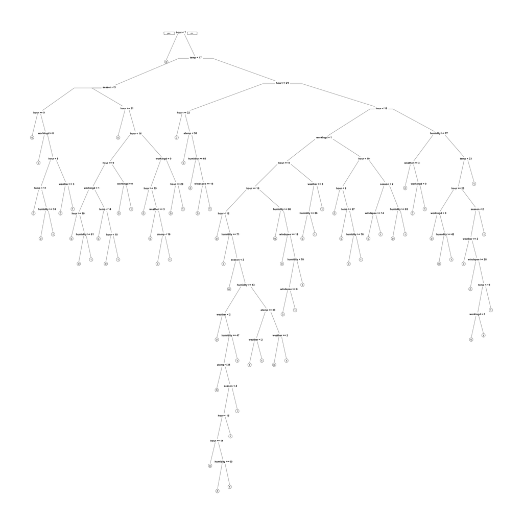

```r
bikes_model_CART = rpart(demand_level ~ . - count - X, bikesTrain, cp=0.001)
prp(bikes_model_CART)
```

- There will be a high demand of bikes before 7 AM.
- **There will not be a high demand of bikes before 7 AM.**
- If the hour is before 7 AM, we should look at the temperature.
- If the hour is before 7 AM and the temperature is less than 17, there will not be a high demand

#### Problem 4.2 - CART

What is the (test) accuracy of your CART model?

```r
bikesTest$holiday = as.factor(bikesTest$holiday)
bikesTest$workingday = as.factor(bikesTest$workingday)
#bikesTrain$weather = as.factor(bikesTrain$weather)
bikesTest$demand_level = as.factor(bikesTest$demand_level)

y_pred = predict(bikes_model_CART, bikesTest,type = 'class')
y_true = bikesTest$demand_level
sum(y_pred==y_true)/nrow(bikesTest)
```

```
## [1] 0.8876301
```

What does the CART model predict on a Saturday, spring day at 9 AM when the temparature is 15 degrees Celsius?

- high demand
- **low demand**
- Not enough information